# Superstore Sales Analysis with R

Camila Pattaro

2025-02-23

## Introduction

Superstore Sales contains information about products, sales, and profits, and it can be found [here](https://public.tableau.com/app/learn/sample-data).

The goal of this project is to answer a number of business questions related to the company’s sales.

*1. How have sales evolved over time?*

*2. What percentage of sales and profit is represented by each category?*

*3. Which product sub-categories have the highest sales?*

*4. Which product sub-category generates the highest sales and which one generates the most profit? What is the relationship between them?*

*5. What are the TOP 10 products according to their sales?*

*6. Which states have the highest sales?*

## Data Preparation

```r
# Loading libraries
library(readxl)
library(janitor)
library(tidyverse)
library(lubridate)
library(dplyr)
library(ggplot2)
library(treemapify)
library(tidyr)
library(sf)
library(scales)
library(maps)
```

```r
# Loading the data
ss <-read_excel("C:\\Users\\camil\\OneDrive\\Documents\\KAGGLE\\sample_-_superstore.xls")
```

```r
# Getting a overview of the data
glimpse(ss)
```

```
## Rows: 9,994
## Columns: 21
## $ `Row ID`        <dbl> 1, 2, 3, 4, 5, 6, 7, 8, 9, 10, 11, 12, 13, 14, 15, 16,…
## $ `Order ID`      <chr> "CA-2016-152156", "CA-2016-152156", "CA-2016-138688", …
## $ `Order Date`    <dttm> 2016-11-08, 2016-11-08, 2016-06-12, 2015-10-11, 2015-…
## $ `Ship Date`     <dttm> 2016-11-11, 2016-11-11, 2016-06-16, 2015-10-18, 2015-…
## $ `Ship Mode`     <chr> "Second Class", "Second Class", "Second Class", "Stand…
## $ `Customer ID`   <chr> "CG-12520", "CG-12520", "DV-13045", "SO-20335", "SO-20…
## $ `Customer Name` <chr> "Claire Gute", "Claire Gute", "Darrin Van Huff", "Sean…
## $ Segment         <chr> "Consumer", "Consumer", "Corporate", "Consumer", "Cons…
## $ Country         <chr> "United States", "United States", "United States", "Un…
## $ City            <chr> "Henderson", "Henderson", "Los Angeles", "Fort Lauderd…
## $ State           <chr> "Kentucky", "Kentucky", "California", "Florida", "Flor…
## $ `Postal Code`   <dbl> 42420, 42420, 90036, 33311, 33311, 90032, 90032, 90032…
## $ Region          <chr> "South", "South", "West", "South", "South", "West", "W…
## $ `Product ID`    <chr> "FUR-BO-10001798", "FUR-CH-10000454", "OFF-LA-10000240…
## $ Category        <chr> "Furniture", "Furniture", "Office Supplies", "Furnitur…
## $ `Sub-Category`  <chr> "Bookcases", "Chairs", "Labels", "Tables", "Storage", …
## $ `Product Name`  <chr> "Bush Somerset Collection Bookcase", "Hon Deluxe Fabri…
## $ Sales           <dbl> 261.9600, 731.9400, 14.6200, 957.5775, 22.3680, 48.860…
## $ Quantity        <dbl> 2, 3, 2, 5, 2, 7, 4, 6, 3, 5, 9, 4, 3, 3, 5, 3, 6, 2, …
## $ Discount        <dbl> 0.00, 0.00, 0.00, 0.45, 0.20, 0.00, 0.00, 0.20, 0.20, …
## $ Profit          <dbl> 41.9136, 219.5820, 6.8714, -383.0310, 2.5164, 14.1694,…
```

```r
# Cleaning and standardizing column names
ss <- clean_names(ss)
colnames(ss)
```

```
##  [1] "row_id"        "order_id"      "order_date"    "ship_date"
##  [5] "ship_mode"     "customer_id"   "customer_name" "segment"
##  [9] "country"       "city"          "state"         "postal_code"
## [13] "region"        "product_id"    "category"      "sub_category"
## [17] "product_name"  "sales"         "quantity"      "discount"
## [21] "profit"
```

```r
# Checking missing values
colSums(is.na(ss))
```

```
##        row_id      order_id    order_date     ship_date     ship_mode
##             0             0             0             0             0
##   customer_id customer_name       segment       country          city
##             0             0             0             0             0
##         state   postal_code        region    product_id      category
##             0             0             0             0             0
##  sub_category  product_name         sales      quantity      discount
##             0             0             0             0             0
##        profit
##             0
```

```r
# Removing duplicate rows
ss <- ss[!duplicated(ss),]
```

## Data Analysis

### 1. How have sales evolved over time?

```r
# Extracting month and year from order_date column
ss$year_month <- format(ss$order_date, "%Y-%m")
head(ss$year_month)
```

```
## [1] "2016-11" "2016-11" "2016-06" "2015-10" "2015-10" "2014-06"
```

```r
# Aggregating total sales by year and month
monthly_sales <- aggregate(sales ~ year_month, data = ss, sum)
head(monthly_sales)
```

```
##   year_month     sales
## 1    2014-01 14236.895
## 2    2014-02  4519.892
## 3    2014-03 55691.009
## 4    2014-04 28295.345
## 5    2014-05 23648.287
## 6    2014-06 34595.128
```

```r
class(ss$year_month)
```

```
## [1] "character"
```

We can see the year_month collumn have the wrong data type.

```r
# Converting year_month to Date by appending "-01" to represent the first day of the month
ss$year_month <- as.Date(paste0(ss$year_month, "-01"), format="%Y-%m-%d")
head(ss$year_month)
```

```
## [1] "2016-11-01" "2016-11-01" "2016-06-01" "2015-10-01" "2015-10-01"
## [6] "2014-06-01"
```

```r
# Convert 'year_month' to Date format
monthly_sales$year_month <- as.Date(paste0(monthly_sales$year_month, "-01"), format="%Y-%m-%d")
head(monthly_sales)
```

```
##   year_month     sales
## 1 2014-01-01 14236.895
## 2 2014-02-01  4519.892
## 3 2014-03-01 55691.009
## 4 2014-04-01 28295.345
## 5 2014-05-01 23648.287
## 6 2014-06-01 34595.128
```

Now we have the right data type.

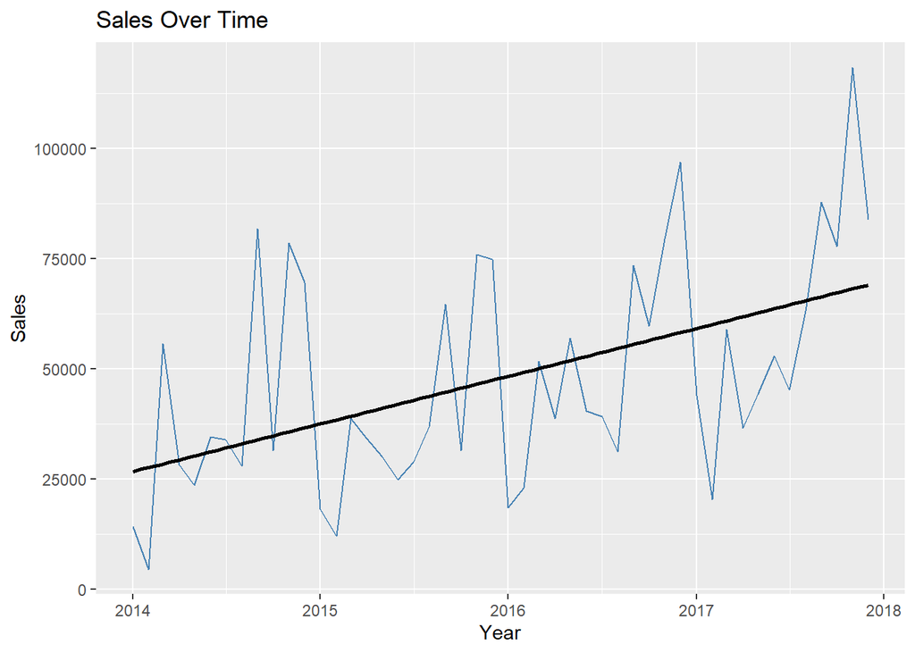

```r
# Creating a line plot with a trend line
ggplot(monthly_sales, aes(x = year_month, y = sales)) +
  geom_line(color = "steelblue") +
  geom_smooth(method = "lm", color = "black", se = FALSE) +
  labs(title = "Sales Over Time", x = "Year", y = "Sales")
```

We observe a **growth** in sales over the years.

### 2. What percentage of sales and profit is represented by each category?

First let`s analyse Sales:

```r
# Grouping sales by category and calculate percentages
category_sales <- ss %>%
  group_by(category) %>%
  summarise(total_sales = sum(sales, na.rm = TRUE)) %>%
  mutate(percentage = (total_sales / sum(total_sales)) * 100)
```

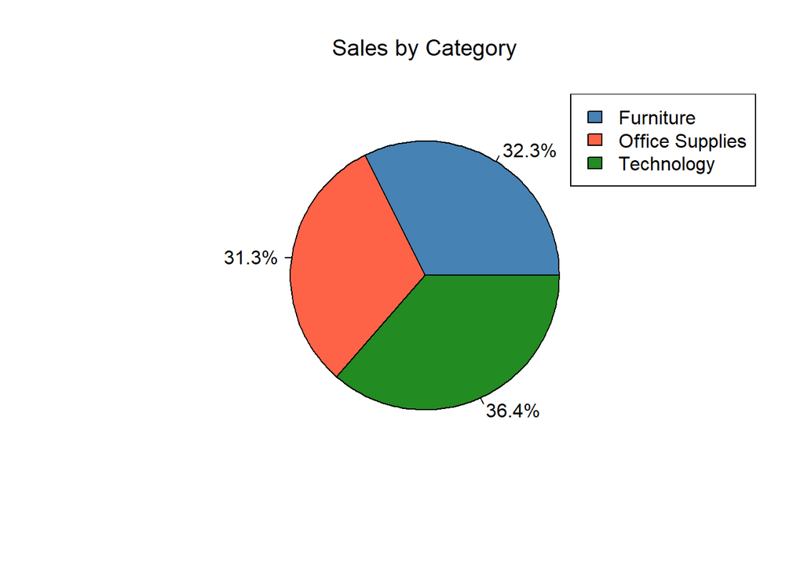

```r
# Creating a pie chart
# Define custom colors (SteelBlue and Tomato)
custom_colors <- c("steelblue", "tomato", "forestgreen")

pie(category_sales$percentage,
    labels = paste0(round(category_sales$percentage, 1), "%"),
    main = "Sales by Category",
    col = custom_colors,
    font.main = 1)
legend("topright", legend = category_sales$category, fill = custom_colors)
```

Then Profits:

```r
# Grouping profit by category and calculate percentages
category_profit <- ss %>%
  group_by(category) %>%
  summarise(total_profit = sum(profit)) %>%
  mutate(percentage = (total_profit / sum(total_profit)) * 100)
```

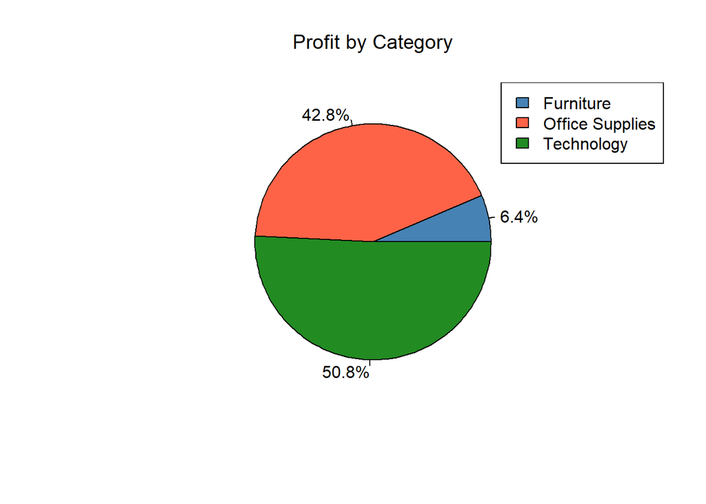

```r
# Creating a pie chart
pie(category_profit$percentage,
    labels = paste0(round(category_profit$percentage, 1), "%"),
    main = "Profit by Category",
    col = custom_colors,
    font.main = 1)
legend("topright", legend = category_sales$category, fill = custom_colors)
```

We can see that sales are distributed almost equally among the categories; however, profits are not. *Technology* accounts for more than half of the total profit, followed by *Office Supplies* with 43%, while *Furniture* represents only 6% of the total profit.

### 3. Which product sub-categories have the highest sales?

```r
# Summarizing sales by sub_category
sub_category_sales <- ss %>%
  group_by(sub_category) %>%
  summarise(total_sales = sum(sales, na.rm = TRUE)) %>%
  mutate(percentage = (total_sales / sum(total_sales))*100)
```

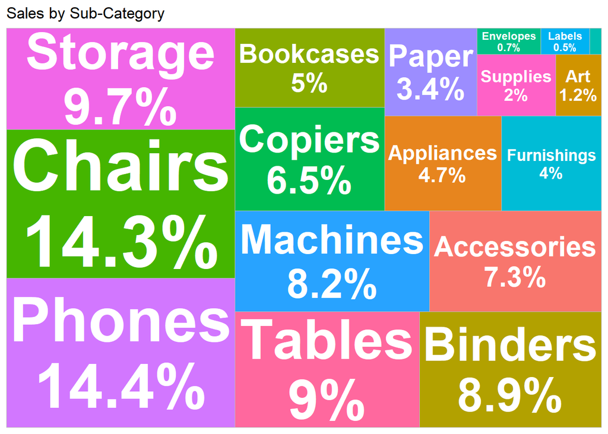

```r
# Creating a treemap
ggplot(sub_category_sales, aes(area = total_sales, fill = sub_category,
                               label = paste0(sub_category, "\n", round(percentage, 1), "%"))) +
  geom_treemap() +
  geom_treemap_text(fontface = "bold", colour = "white", place = "centre", grow = TRUE) +
  labs(title = "Sales by Sub-Category") +
  theme_minimal() +
  theme(legend.position = "none")
```

*Phones* and *Chairs* are the sub-categories with the highest sales, each representing 14% of the total sales.

### 4. Which product sub-category generates the highest sales and which one generates the most profit? What is the relationship between them?

```r
# Summarizing sales and profit by category & sub-category
category_sales_profit <- ss %>%
  group_by(category, sub_category) %>%
  summarise(total_sales = sum(sales, na.rm = TRUE),
            total_profit = sum(profit, na.rm = TRUE),
            .groups = "drop"  # Drop the grouping after summarizing
  ) %>%
  pivot_longer(cols = c(total_sales, total_profit),
               names_to = "metric",
               values_to = "value")  # Convert to long format
```

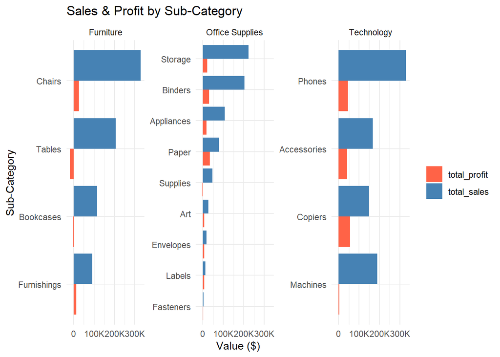

```r
# Creating a side-by-side bar chart
ggplot(category_sales_profit, aes(x = value, y = reorder(sub_category, value), fill = metric)) +
  geom_col(position = "dodge") +
  facet_wrap(~category, scales = "free_y") +
  labs(title = "Sales & Profit by Sub-Category", x = "Value ($)", y = "Sub-Category") +
  theme_minimal() +
  scale_fill_manual(values = c("total_sales" = "steelblue", "total_profit" = "tomato")) +
  scale_x_continuous(labels = label_number(scale_cut = cut_short_scale())) +
  theme(legend.title = element_blank())
```

### 5. What are the TOP 10 products according to their sales?

```r
# Summarizing the top 10 products by total sales
top_products <- ss %>%
  group_by(product_name) %>%
  summarise(total_sales = sum(sales, na.rm = TRUE)) %>%
  arrange(desc(total_sales)) %>%
  slice_head(n = 10)
```

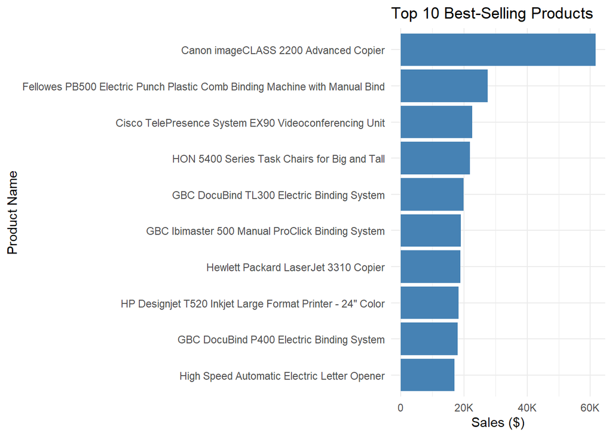

```r
# Creating the horizontal bar chart
ggplot(top_products, aes(x = total_sales, y = reorder(product_name, total_sales))) +
  geom_col(fill = "steelblue") +
  scale_x_continuous(labels = label_number(scale_cut = cut_short_scale())) +
  labs(title = "Top 10 Best-Selling Products", x = "Sales ($)", y = "Product Name") +
  theme_minimal()
```

*The Canon imageCLASS 2200 Advanced Copier* sells twice as much as the second-best product.

### 6. Which states have the highest sales?

```r
# Summarizing sales by state
state_sales <- ss %>%
  group_by(state) %>%
  summarise(total_sales = sum(sales, na.rm = TRUE))
```

```r
# Using the 'maps' package to get a map of US states
us_states_map <- map_data("state")
```

```r
# Merging the sales data with the map data (by state)
state_sales$region <- tolower(state_sales$state)  # Ensure state names match
merged_data <- left_join(us_states_map, state_sales, by = "region")
```

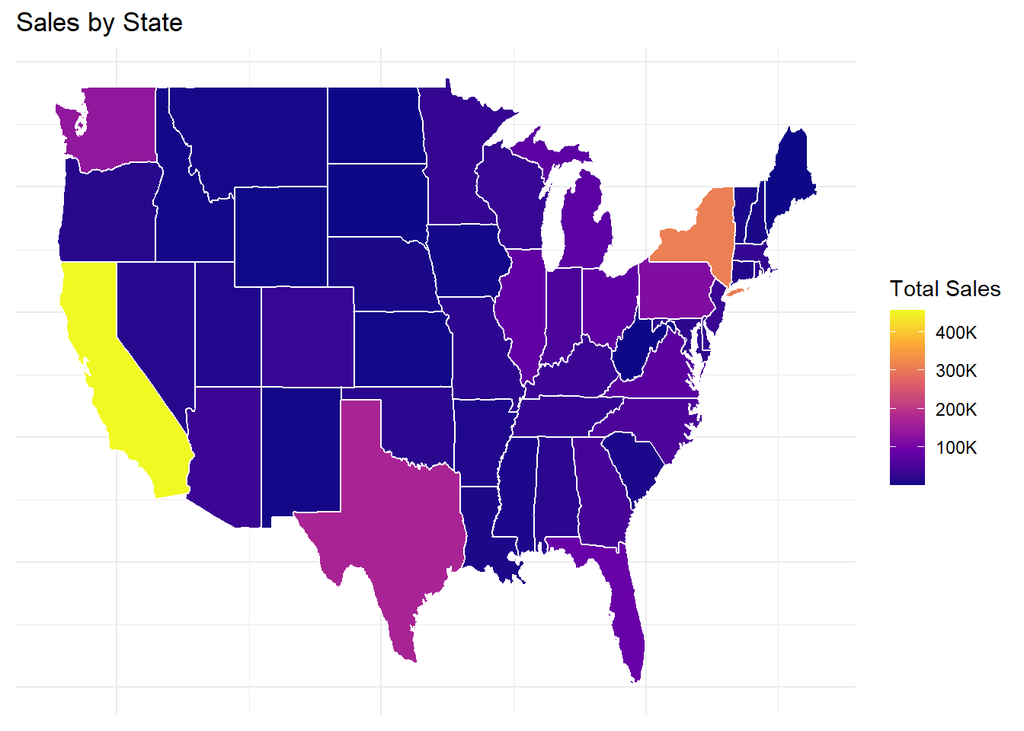

```r
# Creating a choropleth map
ggplot(merged_data, aes(x = long, y = lat, group = group, fill = total_sales)) +
  geom_polygon(color = "white") +
  scale_fill_viridis_c(option = "C", labels = label_number(scale_cut = cut_short_scale())) +
  theme_minimal() +
  labs(title = "Sales by State", fill = "Total Sales") +
  theme(axis.text = element_blank(), axis.title = element_blank())
```

California is the state with the highest sales, surpassing $400,000. New York ranks second, with approximately $300,000 in sales.